# Introducción a la programación y análisis de datos en R

Día 1 · Bloque 2 — R como calculadora, variables, tipos de datos, vectores, `NA` e indexación

Filip Andras

CIMCYC — Universidad de Granada

9 octubre 2026

## ¿Alguna duda pendiente del bloque anterior?

Por pequeña que sea.

## Mapa del día 1

Bloque 1  
9:00 – 10:30

Bienvenida

Programar en la era de la IA

¿Qué es R?

RStudio

Instalar y configurar

Ej. 1–4

Bloque 2  
11:00 – 12:30

R como calculadora

Variables

Ej. 5

Tipos de datos

Ej. 6

Vectores

El problema de `NA`

Ej. 7

Indexación

Ej. 8

Bloque 3  
13:00 – 14:00 · 60’

Data frames

Ej. 9–10

Paquetes

Importar datos

Exploración inicial

Ej. 11

# R como calculadora

[figure not shown]

[figure not shown]

## R como calculadora

- Lo más básico que podemos hacer con R: operaciones aritméticas y **usarlo como una calculadora**.
- Suma

```r
2 + 2
```

```
[1] 4
```

¿Qué significa el `[1]`? Es el **índice** del primer elemento del resultado.

## Suma y resta

```r
10 + 30    # Suma
```

```
[1] 40
```

```r
10 - 20    # Resta
```

```
[1] -10
```

## Multiplicación y división

```r
10 * 20    # Multiplicar
```

```
[1] 200
```

```r
10 / 3     # Dividir
```

```
[1] 3.333333
```

## Potencias y Raices

```r
10 ^ 2     # 10 al cuadrado
```

```
[1] 100
```

```r
2 ^ 10     # 2 a elevado a la 10
```

```
[1] 1024
```

```r
sqrt(16)   # raíz cuadrada de 16
```

```
[1] 4
```

```r
16 ^ (1/2)  # raíz cuadrada de 16
```

```
[1] 4
```

## Resumen de operadores aritméticos

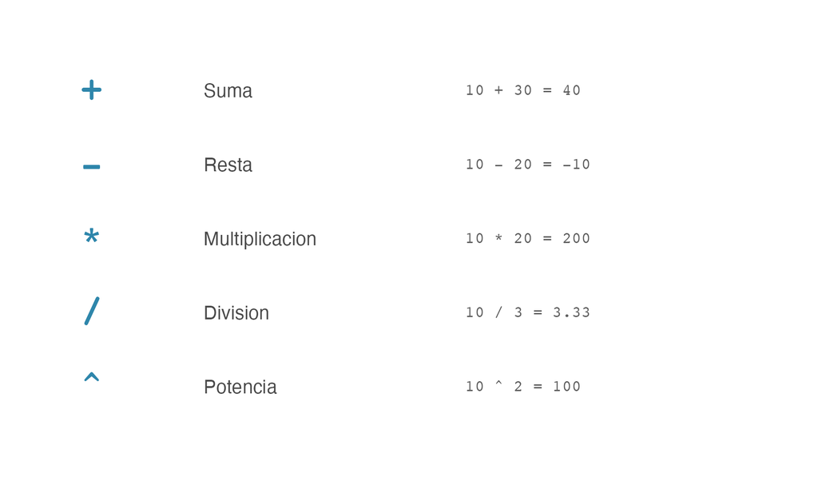

## Orden de operaciones

- R sigue las reglas matemáticas estándar: **PEMDAS** *(Paréntesis, Exponentes, Multiplicación/División, Adición/Sustracción)*

```r
1 + 2 * 4        # Primero las multiplicaciones y divisiones
```

```
[1] 9
```

```r
(1 + 2) * 4      # Primero los paréntesis
```

```
[1] 12
```

## Funciones matemáticas útiles

**¿Qué es una función?**

Una función es un bloque de código que recibe **inputs** (argumentos), realiza una serie de **operaciones** y devuelve un **resultado**.

```r
sqrt(225)            # square root - Raíz cuadrada
```

```
[1] 15
```

```r
abs(-13)             # absolute value - valor absoluto
```

```
[1] 13
```

```r
round(3.14159, 2)    # redondear a dos decimales
```

```
[1] 3.14
```

## Logaritmos y combinaciones

```r
log(100)             # natural logarithm
```

```
[1] 4.60517
```

Las funciones se pueden **anidar** (combinar): la de dentro se evalúa primero, como cajas dentro de cajas.

```r
round(sqrt(1 + abs(-20)), 2)
```

```
[1] 4.58
```

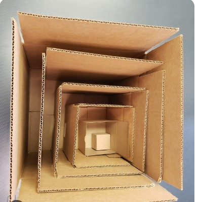

## División entera y módulo

```r
17/5        # división normal: ¿cuánto es 17 dividido por 5?
```

```
[1] 3.4
```

```r
17 %/% 5    # división integer: ¿Cuántas veces cabe 5 en 17?
```

```
[1] 3
```

```r
17 %% 5     # Módulo (remainder): ¿qué sobra luego de dividir 17 por 5?
```

```
[1] 2
```

## R informa de los errores: Leer detenidamente el mensaje

- Los errores son **normales** y **frecuentes**.
- Dejar operaciones abiertas

```r
10 +      # ERROR: falta un número después del +
```

Si olvidan cerrar un paréntesis o completar una operación, la consola muestra `+` esperando más input. Pulsar **Escape** para terminar la operación.

- Errores de ortografía

```r
sqtr(25)    # Si se cometer un error en la escritura
```

```
Error in `sqtr()`:
! could not find function "sqtr"
```

# Variables

## ¿Qué es una variable? (también se llama **objeto**)

- Una forma de guardar datos o información en la memoria de R: un **nombre** que guarda un **valor**.

```r
edad <- 25
```

nombre

`edad`

`<-`guarda

valor

`25`

- Para ver el valor guardado, escribimos el nombre:

```r
edad
```

```
[1] 25
```

## Crear más variables

```r
altura <- 1.75
peso   <- 70
```

Ahora tenemos tres variables en nuestro **Environment**:

- `edad` → 25
- `altura` → 1.75
- `peso` → 70

## Operar con variables

Podemos usar las variables como si fueran números:

```r
# calcular el IMC (indice de masa corporal)
imc <- peso / altura^2
imc
```

```
[1] 22.85714
```

## Las variables se pueden actualizar

```r
edad
```

```
[1] 25
```

```r
edad <- 26    # actualizamos o cambiamos el valor
edad
```

```
[1] 26
```

El valor **anterior** se pierde. R solo guarda el último valor asignado.

## ¿Por qué `<-` y no `=`?

- **Historia**: R hereda `<-` de S, y S de APL, un lenguaje de los años 60 con un teclado propio que tenía una tecla `←`. Y `=` ya estaba ocupado: entonces servía para comparar
- **Hoy**: `<-` asigna, `=` liga argumentos de una función y `==` compara. `mean(x = ...)` no crea ninguna `x`
- Ambos asignan en la mayoría de casos, pero `<-` es la **convención** en R

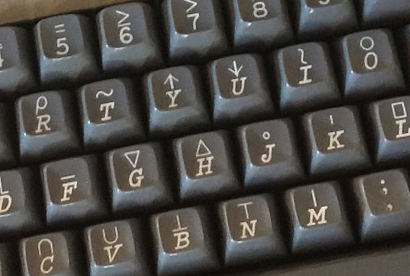

Teclado APL: cada tecla lleva un símbolo propio, entre ellos `←`

Atajo de teclado: **Alt + -** (Windows) / **Option + -** (Mac)

```r
mean(x = c(1, 2, 3))    # x es un ARGUMENTO de mean()
```

```
[1] 2
```

```r
x <- c(1, 2, 3)         # x es una VARIABLE en el entorno
```

## Ejercicio 5 — operaciones con variables

Tiempo: 8 minutos

**Abre ahora el script de ejercicios del día 1**

Con el proyecto `exercises.Rproj` abierto, abre desde el panel Files el archivo `scripts/01_day1_exercises_student.R`. Ahí encontrarás todos los ejercicios del día — iremos resolviéndolos juntos a lo largo de los tres bloques.

1. Crea una variable llamada `edad` y asígnale el valor 25.
2. Calcula el doble de esa edad y guarda el resultado en una nueva variable llamada `doble_edad`.
3. Calcula la raíz cuadrada de la edad usando una función de R y guarda el resultado en una variable llamada `raiz_edad`.
4. Divide la edad entre 3 y redondea el resultado a 2 decimales. Guarda el resultado en una variable llamada `edad_redondeada`.
5. Finalmente, ejecuta cada una de las variables (`doble_edad`, `raiz_edad`, `edad_redondeada`) para ver sus resultados en la consola.

## Reglas para nombres de variables

- Pueden contener **letras**, **números**, `.` y `_`
- **No** pueden empezar con un número
- **No** pueden contener espacios
- R es **case-sensitive**: `myVar` ≠ `myvar`

## “Buenos” y “malos” nombres

Estilo recomendado: **snake_case** (minúsculas, separado por `_`)

```r
# Buenos nombres (descriptivos, snake_case)
tiempo_reaccion <- 450
n_participantes <- 30
```

```r
# Malos nombres (dan error)
2a_medida <- 10       # ERROR: empieza con un numero
mi variable <- 5      # ERROR: contiene un espacio
```

## Errores comunes — nombres de variables inválidos (1/2)

```r
# error 1: empezar con un numero
2nd_measure <- 10
```

```
Error in parse(text = input): <text>:2:2: unexpected symbol
1: # error 1: empezar con un numero
2: 2nd_measure
    ^
```

```r
# error 2: contener espacios
my variable <- 5
```

```
Error in parse(text = input): <text>:2:4: unexpected symbol
1: # error 2: contener espacios
2: my variable
      ^
```

## Errores comunes — nombres de variables inválidos (2/2)

```r
# error 3: usar guiones (R interpreta como resta)
my-variable <- 5
```

```
Error:
! object 'my' not found
```

**Solución:** usa `snake_case`, empieza con letra, y usa `_` en lugar de espacios o guiones.

# Tipos de datos

## Los cuatro tipos básicos

Una variable guarda un **valor**, y ese valor es siempre de uno de **cuatro tipos básicos**:

nombre

`x`

`<-`guarda

numeric

`3.14`

integer

`5L`

character

`"hola"`

logical

`TRUE`

## Tipo: `numeric`

Los números decimales son el tipo más común:

```r
x <- 3.14
class(x)
```

```
[1] "numeric"
```

Todos los números “normales” en R son `numeric` por defecto.

**¿Y `double`?**

Técnicamente, R almacena los `numeric` como **`double`** (números de coma flotante de 64 bits, estándar IEEE 754). Puedes verlo con `typeof(3.14)`, que devuelve `"double"`, mientras que `class(3.14)` devuelve `"numeric"`. Para fines prácticos en este curso, `numeric` y `double` son intercambiables.

## Tipo: `integer`

- Los números enteros llevan una **L** al final (sin decimales).
- `numeric` e `integer` suelen ser intercambiables (pero `integer` es más eficiente para índices y conteos).

```r
x <- 5L
class(x)
```

```
[1] "integer"
```

## Tipo: `character`

El texto siempre va entre **comillas** (simples o dobles):

```r
x <- "hola mundo"
class(x)
```

```
[1] "character"
```

```r
# CBT = Cognitive Behavioral Therapy (terapia cognitivo-conductual)
grupo <- "CBT"
class(grupo)
```

```
[1] "character"
```

## Tipo: `logical`

Solo dos valores posibles: `TRUE` o `FALSE`

```r
x <- TRUE
y <- FALSE
class(x)
```

```
[1] "logical"
```

Se combinan con `&` (y), `|` (o) y `!` (no), y son el resultado de cualquier comparación:

```r
x & y     # TRUE y FALSE -> FALSE
```

```
[1] FALSE
```

```r
5 > 3     # una comparacion devuelve un logical
```

```
[1] TRUE
```

## Tabla resumen de tipos

| Tipo | Ejemplo | Uso típico |
| --- | --- | --- |
| `numeric` | `3.14`, `100` | Medidas, puntuaciones, tiempos de reacción |
| `integer` | `5L`, `10L` | Conteos, índices |
| `character` | `"hola"`, `"CBT"` | Nombres, etiquetas, condiciones |
| `logical` | `TRUE`, `FALSE` | Filtros, indicadores |
| `factor` *(derivado)* | `factor(c("CBT", "control"))` | Variables categóricas con niveles fijos: grupo, condición |

`factor` no es un tipo básico: por dentro es un `integer` con una etiqueta por nivel. Es como R representa una variable **categórica** en modelos y gráficos (lo usaremos con los data frames).

## Comprobar tipos: `class()` e `is.*()`

```r
is.numeric(3.14)
```

```
[1] TRUE
```

```r
is.character("hola")
```

```
[1] TRUE
```

```r
is.logical(TRUE)
```

```
[1] TRUE
```

```r
class(factor(c("CBT", "control")))   # class() tambien reconoce el tipo derivado
```

```
[1] "factor"
```

## Convertir tipos: `as.*()`

```r
as.character(42)        # número -> texto
```

```
[1] "42"
```

```r
as.numeric("3.14")      # texto -> número
```

```
[1] 3.14
```

## ¿Qué pasa si la conversión no tiene sentido?

```r
as.numeric("hola")      # NA + warning
```

```
[1] NA
```

**Cuidado con NA**

`NA` significa “dato ausente”. Aparece cuando R no puede hacer una conversión o cuando faltan datos. Lo veremos mucho en los próximos días.

## Comparaciones y operadores lógicos

Las comparaciones devuelven `TRUE` o `FALSE`:

```r
5 > 3          # mayor que
```

```
[1] TRUE
```

```r
5 == 5         # igual que (doble =)
```

```
[1] TRUE
```

```r
5 != 3         # diferente de
```

```
[1] TRUE
```

## Operadores lógicos

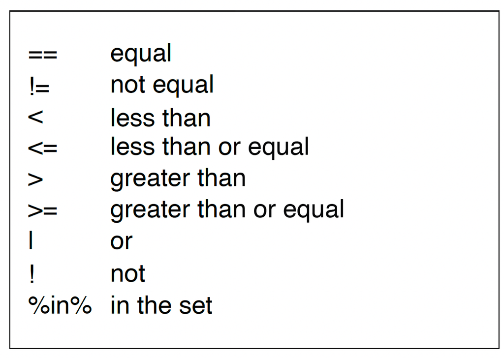

**Tener en cuenta:**

`==` compara, `=` nombra argumentos dentro de una función (`mean(x = ...)`), `<-` asigna. Son tres cosas diferentes.

## Algunos atajos de teclado útiles

- `Tools` → `Keyboard shortcut help` (`Option/Alt + Shift + K`)

| Acción | Mac | Windows / Linux |
| --- | --- | --- |
| Ejecutar línea actual | `Cmd + Enter` | `Ctrl + Enter` |
| Insertar `<-` | `Opt + -` | `Alt + -` |
| Comentar/descomentar | `Cmd + Shift + C` | `Ctrl + Shift + C` |
| Autocompletar | `Tab` | `Tab` |
| Guardar script | `Cmd + S` | `Ctrl + S` |
| Selección en columna | `Opt + clic/arrastrar` | `Alt + clic/arrastrar` |

**Comentarios: `#`**

Una línea que empieza por `#` es un **comentario**: R la ignora. Sirve para explicar el código, y para desactivar una línea sin borrarla. El atajo pone o quita la `#` en la línea (o líneas) donde esté el cursor.

## Ejercicio 6 — calculadora de IMC

Tiempo: 15 minutos

**Seguimos con el script de ejercicios del día 1**

En el archivo `exercises/scripts/01_day1_exercises_student.R`. Busca el ejercicio 6 y el ejercicio Extra del Bloque 2.

**Instrucciones:**

1. Crea variables para tu nombre, edad, altura (m) y peso (kg)
2. Calcula tu IMC: `peso / altura^2`
3. Comprueba el tipo de cada variable con `class()`
4. Convierte tu edad a character con `as.character()` y comprueba qué cambió
5. Crea una variable lógica: `es_mayor <- edad > 18`

**Si te sobra tiempo**

1. Calcula la raíz cuadrada de 144
2. Comprueba el tipo de dato que devuelve `sqrt()`
3. Crea dos variables lógicas (`tengo_dinero`, `tengo_entrada`) y prueba `&`, `|`, `!` entre ellas
4. Crea la variable `puedo_entrar`, usando las variables anteriores, y cuyo resultado sea igual a `TRUE`

## Resumen intermedio: calculadora, variables y tipos

- **RStudio** tiene 4 paneles: Files, Source, Console y el panel de pestañas (Environment, Plots, Packages, Help…)
- R funciona como **calculadora**: `+`, `-`, `*`, `/`, `^`, `sqrt()`, `abs()`
- Asignamos con `<-` y usamos `snake_case` para nombres
- Hay 4 **tipos básicos de variables**: `numeric`, `integer`, `character`, `logical`
- Comprobamos con `class()` / `is.*()`, convertimos con `as.*()`
- Las **comparaciones** (`>`, `==`, `!=`) devuelven lógicos

# Tipo de estructuras de datos en R

## Estructuras de datos básicas

En R, los datos se organizan en **estructuras de datos**. Las más básicas son:

- **Vectores**: secuencias de valores del mismo tipo (numéricos, caracteres, lógicos)
- **Matrices**: tablas bidimensionales de valores del mismo tipo
- **Arrays**: Matrices con más de 2 dimensiones
- **Data frames**: tablas bidimensionales con diferentes tipos de valores (en las columnas)
- **Listas**: colecciones de objetos de cualquier tipo (vectores, data frames anidados, etc.)

[Data Structures in R (from Zimmermann & Steinmann 2006)](https://eol.pages.cms.hu-berlin.de/geo_rs/S00_r-basics.html)

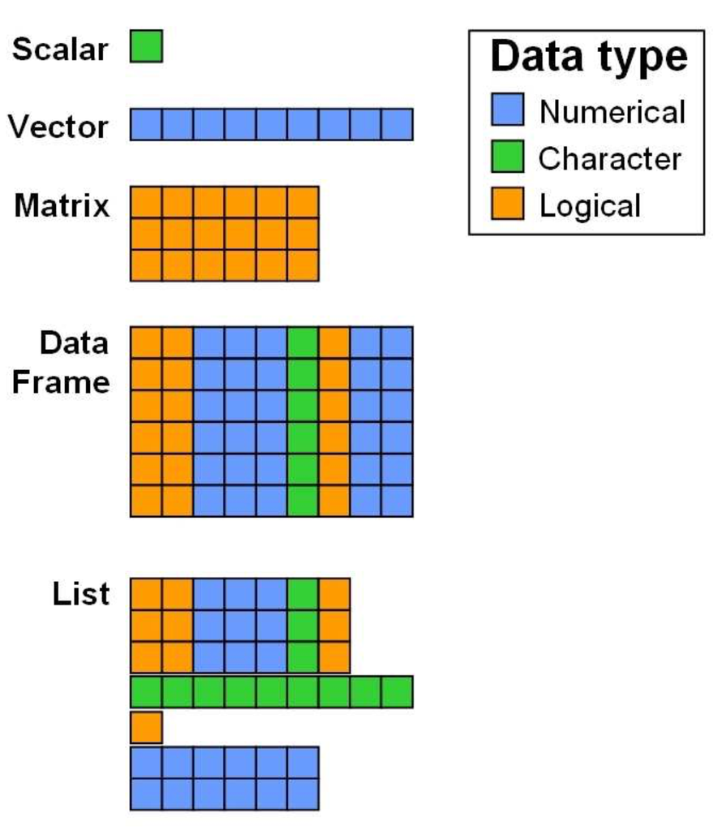

# Vectores

## ¿Qué es un vector?

Un **vector** es una secuencia ordenada de valores del **mismo tipo**.

- Es la estructura de datos más básica en R — todo lo que hemos hecho hasta ahora (variables con un valor) son en realidad vectores de longitud 1.

```r
# una variable simple es un vector de longitud 1
edad <- 25
length(edad) # longitud del vector
```

```
[1] 1
```

## Crear un vector con la función *Combine* `c()` (1/2)

nombre_vector <- c(valor1, valor2, valor3, …)

```r
# vector de edades de pacientes
edades <- c(25, 32, 18, 45, 28)
edades
```

```
[1] 25 32 18 45 28
```

```r
length(edades)
```

```
[1] 5
```

## Crear un vector con la función *Combine* `c()` (2/2)

nombre_vector <- c(valor1, valor2, valor3, …)

```r
# vector de etiquetas de grupo (texto, entre comillas)
grupos <- c("CBT", "placebo", "CBT", "control", "placebo")
grupos
```

```
[1] "CBT"     "placebo" "CBT"     "control" "placebo"
```

```r
length(grupos)
```

```
[1] 5
```

## Vectorización

Las operaciones se aplican a **cada elemento** del vector — sin bucles:

vector * constante

→ cada elemento multiplicado por la constante

vector - mean(vector)

→ cada elemento menos la media del vector

```r
# tiempos de reacción en milisegundos
tiempos_reaccion <- c(450, 380, 520, 410, 490)

# convertir a segundos: dividimos cada elemento entre 1000
tiempos_reaccion / 1000
```

```
[1] 0.45 0.38 0.52 0.41 0.49
```

```r
# centrar: restamos la media a cada valor
tiempos_reaccion - mean(tiempos_reaccion)
```

```
[1]   0 -70  70 -40  40
```

## Vectores numéricos: operaciones vectorizadas

- Permite realizar operaciones elemento a elemento sobre todos los valores de un vector (sin bucles, cuando son del mismo tamaño)

```r
x <- c(1, 2, 3, 4) # un vector de cuatro valores
y <- c(6, 7, 8, 9) # un vector de cuatro valores
z <- x + y        # suma elemento a elemento
z
```

```
[1]  7  9 11 13
```

## Vectores numéricos: operaciones vectorizadas

- **Recicla** los valores cuando los vectores no son de la misma longitud.

```r
x <- c(1, 2, 3, 4)  # un vector de cuatro valores
y <- c(6, 7)        # un vector de dos valores
z <- x + y          # suma reciclando y: (1+6, 2+7, 3+6, 4+7)
z
```

```
[1]  7  9  9 11
```

## ¿Qué es una función?

Una función es una **máquina**: recibe **argumentos** (la entrada), hace algo con ellos y **devuelve un resultado** (la salida).

función

`mean( )`

→

resultado

`29.6`

↑

argumentos

`x = edades`

nombre_de_la_funcion(argumento = valor, otro_argumento = valor)

```r
edades <- c(25, 32, 18, 45, 28)
mean(x = edades)
```

```
[1] 29.6
```

## Argumentos: con nombre o por posición

Las dos llamadas son **equivalentes**: sin nombre, R empareja los valores **por posición**. Con varios argumentos la diferencia importa:

```r
mean(x = edades)    # con nombre
mean(edades)        # por posición
```

```r
round(x = 3.14159, digits = 2)   # claro: sabes qué es cada cosa
round(3.14159, 2)                # funciona, pero hay que recordar el orden
```

```
[1] 3.14
[1] 3.14
```

**Convención del curso**

En este curso escribimos **siempre el nombre del argumento** (`mean(x = edades)`), aunque R no lo exija. Se lee mejor, no depende del orden y es lo que verás en la ayuda: `?mean` muestra los argumentos (*Usage*, *Arguments*), lo que devuelve (*Value*) y ejemplos.

## Descriptivos de un vector: `mean()`, `sd()`, `median()`

mean(vector)

→ media aritmetica

sd(vector)

→ desviacion tipica

median(vector)

→ mediana

```r
puntuaciones <- c(45, 62, 38, 71, 55, 49, 83, 60, 42, 67)
mean(puntuaciones)     # media aritmetica
sd(puntuaciones)       # desviacion tipica
median(puntuaciones)   # mediana
```

```
[1] 57.2
[1] 14.15627
[1] 57.5
```

## Descriptivos de un vector: `min()`, `max()`, `range()`

```r
min(puntuaciones)       # mínimo
```

```
[1] 38
```

```r
max(puntuaciones)       # máximo
```

```
[1] 83
```

```r
range(puntuaciones)     # mínimo y máximo juntos
```

```
[1] 38 83
```

## Todo de una vez: `summary()`

- `summary()` es la forma más rápida de tener una primera impresión de los datos: mínimo, cuartiles, media y máximo.

```r
summary(puntuaciones)
```

```
   Min. 1st Qu.  Median    Mean 3rd Qu.    Max.
  38.00   46.00   57.50   57.20   65.75   83.00
```

## Ver la distribución: histograma `hist()`

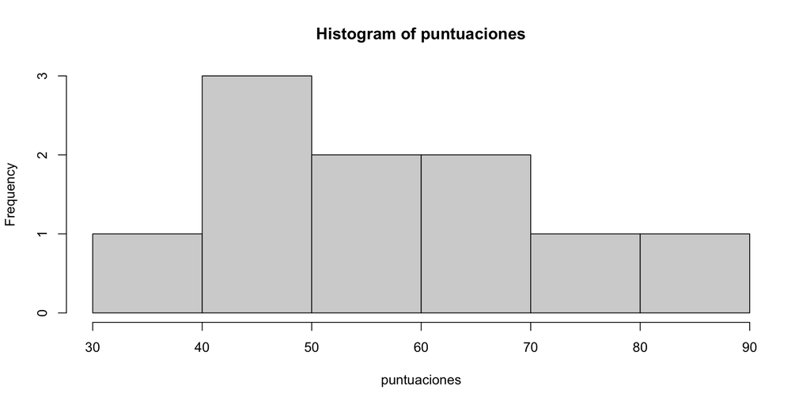

```r
hist(puntuaciones)
```

## Ver la distribución: boxplot `boxplot()`

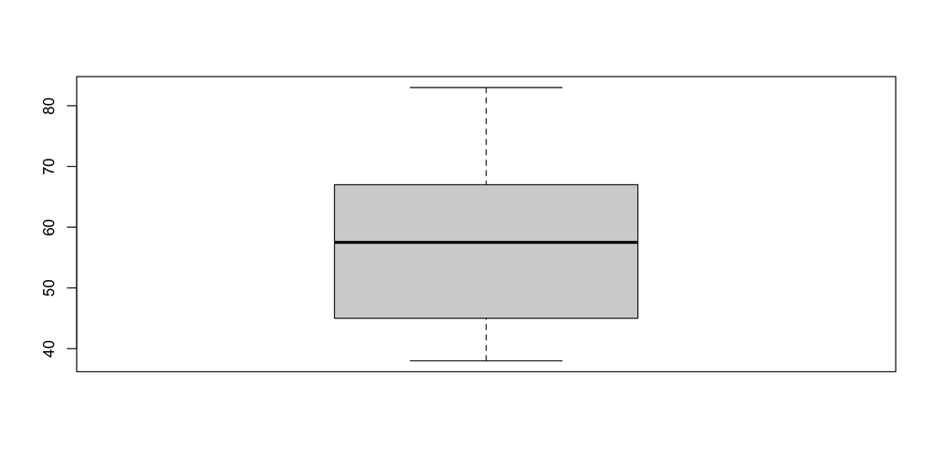

```r
boxplot(puntuaciones)
```

## Ver la distribución: dotplot `plot()`

```r
puntuaciones
```

```
 [1] 45 62 38 71 55 49 83 60 42 67
```

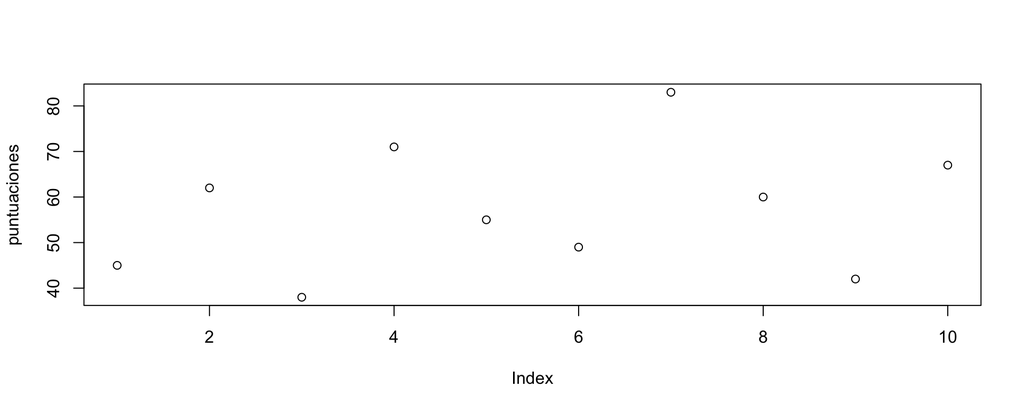

```r
plot(puntuaciones)
```

## Contar y sumar

```r
length(puntuaciones)    # número de elementos en el vector
```

```
[1] 10
```

```r
sum(puntuaciones)       # suma total de todos los elementos del vector
```

```
[1] 572
```

## Contar con una comparación

Una comparación sobre un vector devuelve un vector de `TRUE`/`FALSE`, uno por elemento:

```r
puntuaciones <- c(45, 62, 38, 71, 55, 49, 83, 60, 42, 67)
puntuaciones > 50
```

```
 [1] FALSE  TRUE FALSE  TRUE  TRUE FALSE  TRUE  TRUE FALSE  TRUE
```

Y `sum()` cuenta los `TRUE`, porque R los trata como `1` (y `FALSE` como `0`):

`puntuaciones`

45

62

38

71

55

49

83

60

42

67

`puntuaciones > 50`

FALSE

TRUE

FALSE

TRUE

TRUE

FALSE

TRUE

TRUE

FALSE

TRUE

para `sum()`: `TRUE` = 1, `FALSE` = 0

0

1

0

1

1

0

1

1

0

1

= 6

```r
sum(puntuaciones > 50)   # cuántos tienen puntuación superior a 50
```

```
[1] 6
```

## Combinar condiciones: `&` y `|`

```r
# cuántos tienen puntuación entre 50 y 70? (las dos condiciones a la vez: &)
sum(puntuaciones >= 50 & puntuaciones <= 70)
```

```
[1] 4
```

```r
# cuántos están fuera del rango 40-70? (una condición u otra: |)
sum(puntuaciones < 40 | puntuaciones > 70)
```

```
[1] 3
```

```r
# y qué proporción? mean() de un vector lógico = proporción de TRUE
mean(puntuaciones > 50)
```

```
[1] 0.6
```

# El problema de `NA`

## ¿Qué es `NA`?

- `NA` (*Not Available*) representa un **dato perdido** en R.

```r
imc <- c(22.5, 27.1, NA, 31.4, 19.8)
imc
```

```
[1] 22.5 27.1   NA 31.4 19.8
```

- Identificar y contar `NA`

```r
is.na(imc)      # identifica los NA en el vector
```

```
[1] FALSE FALSE  TRUE FALSE FALSE
```

```r
sum(is.na(imc)) # cuenta cuántos NA hay en el vector
```

```
[1] 1
```

## El problema: `NA` se contagia

Si un vector tiene un `NA`, casi cualquier cálculo con él devuelve `NA`: R no sabe qué valor falta, así que tampoco puede saber el resultado.

`imc`

22.5

27.1

NA

31.4

19.8

`mean(x = imc)`

(22.5 + 27.1 + NA + 31.4 + 19.8) / 5

= NA

```r
mean(x = imc)
```

```
[1] NA
```

## La solución: `na.rm = TRUE`

Muchas funciones tienen el argumento `na.rm` (*remove NA*): con `TRUE`, ignoran los `NA` antes de calcular.

mean(x = vector, na.rm = TRUE)

→ media ignorando los NA

sd(x = vector, na.rm = TRUE)

→ desviación típica ignorando los NA

```r
mean(x = imc, na.rm = TRUE)
```

```
[1] 25.2
```

```r
sd(x = imc, na.rm = TRUE)
```

```
[1] 5.115336
```

**Buena práctica**

Usa siempre `na.rm = TRUE` con `mean()`, `sd()`, `sum()`, etc. para evitar problemas en las operaciones con datos ausentes.

## Ejercicio 7 — contar `NA` y calcular la media

Tiempo: 5 minutos

Tienes este vector de puntuaciones **BAI** (*Beck Anxiety Inventory*, inventario de ansiedad de Beck) con valores ausentes:

```r
bai <- c(12, NA, 28, 7, NA, 45, 19)
```

1. ¿Cuántos `NA` hay? Usa `sum(is.na())`.
2. ¿Qué devuelve `mean(bai)`? ¿Por qué?
3. Calcula la media ignorando los `NA`.

# Selección de elementos (indexación)

## La lógica de `[ ]`

- Siempre podemos explorar la ayuda de R para entender cómo funciona algo

```r
help("[")
```

Para seleccionar elementos de un vector usamos **corchetes** `[ ]`:

vector[posicion]

→ un solo elemento

vector[c(pos1, pos2)]

→ varios elementos

vector[inicio:fin]

→ un rango

vector[condicion_logica]

→ todos los que cumplen la condicion

**Nota**

En R los índices **empiezan en 1** (no en 0, como en Python).

## Indexación por valores

```r
bai <- c(12, 28, 7, 45, 19)
bai[4]
```

```
[1] 45
```

posición

[1]

[2]

[3]

[4]

[5]

`bai`

12

28

7

45

19

`bai[4]`

45

= 45

## Indexación por rangos

```r
bai <- c(12, 28, 7, 45, 19)
```

```r
# elementos 2 al 4 (rango)
bai[2:4]
```

```
[1] 28  7 45
```

```r
# excluir el primer elemento (índice negativo)
bai[-1]
```

```
[1] 28  7 45 19
```

## Errores comunes — indexación de vectores (1/3)

```r
bai <- c(12, 28, 7, 45, 19)
```

```r
# error 1: indice 0 (R empieza en 1, no en 0 como Python)
bai[0]
```

```
numeric(0)
```

```r
# error 2: indice fuera de rango (devuelve NA, no un error)
bai[10]
```

```
[1] NA
```

## Errores comunes — indexación de vectores (2/3)

```r
bai <- c(12, 28, 7, 45, 19)
```

```r
# error 3: mezclar indices positivos y negativos
bai[c(1, -2)]
```

```
Error in `bai[c(1, -2)]`:
! only 0's may be mixed with negative subscripts
```

## Errores comunes — indexación de vectores (3/3)

```r
bai <- c(12, 28, 7, 45, 19)
```

```r
# error 4: usar valores separados como indices
bai[1, 3]
```

```
Error in `bai[1, 3]`:
! incorrect number of dimensions
```

```r
# deben ir concatenados con c()
bai[c(1, 3)]
```

```
[1] 12  7
```

## Indexación lógica: los valores que cumplen

vector[condicion]

→ los VALORES que cumplen la condicion

```r
puntuaciones <- c(45, 62, 38, 71, 55, 49, 83, 60, 42, 67)

# que valores son mayores que 60?
puntuaciones[puntuaciones > 60]
```

```
[1] 62 71 83 67
```

`puntuaciones`

45

62

38

71

55

49

83

60

42

67

`puntuaciones > 60`

FALSE

TRUE

FALSE

TRUE

FALSE

FALSE

TRUE

FALSE

FALSE

TRUE

`puntuaciones[puntuaciones > 60]`

62

71

83

67

## Quedarse con los valores válidos: `!is.na()`

`!` significa **no**: invierte cada `TRUE`/`FALSE`. Por eso `!is.na(x)` marca los valores que **sí** tenemos.

```r
imc <- c(22.5, 27.1, NA, 31.4, 19.8)
!is.na(imc)        # TRUE donde NO hay NA
```

```
[1]  TRUE  TRUE FALSE  TRUE  TRUE
```

```r
imc[!is.na(imc)]   # solo los valores validos
```

```
[1] 22.5 27.1 31.4 19.8
```

`imc`

22.5

27.1

NA

31.4

19.8

`is.na(imc)`

FALSE

FALSE

TRUE

FALSE

FALSE

`!is.na(imc)`

TRUE

TRUE

FALSE

TRUE

TRUE

`imc[!is.na(imc)]`

22.5

27.1

31.4

19.8

## Modificar elementos: por posición

Con `[ ]` a la izquierda de `<-` no seleccionamos: **reemplazamos** lo seleccionado.

```r
edades <- c(25, 32, 18, 45, 28)

# cambiar el segundo elemento
edades[2] <- 33
edades
```

```
[1] 25 33 18 45 28
```

## Modificar elementos: por condición (1/2)

Un caso muy frecuente: el vector tiene un `NA` y queremos **sustituirlo por la media de los demás valores**. Son tres pasos:

```r
imc <- c(22.5, 27.1, NA, 31.4, 19.8)

# paso 1: donde esta el NA? (TRUE en esa posicion)
is.na(imc)
```

```
[1] FALSE FALSE  TRUE FALSE FALSE
```

```r
# paso 2: el valor que vamos a poner (la media de los demas)
mean(x = imc, na.rm = TRUE)
```

```
[1] 25.2
```

## Modificar elementos: por condición (2/2)

Paso 3: `[ ]` selecciona las posiciones con `TRUE` y `<-` les asigna ese valor.

```r
imc[is.na(imc)] <- mean(x = imc, na.rm = TRUE)
imc
```

```
[1] 22.5 27.1 25.2 31.4 19.8
```

`imc`

22.5

27.1

NA

31.4

19.8

`is.na(imc)`

FALSE

FALSE

TRUE

FALSE

FALSE

`imc[is.na(imc)] <- 25.2`

22.5

27.1

25.2

31.4

19.8

## Ejercicio 8 — analizar puntuaciones de ansiedad

Tiempo: 20 minutos

Tienes las puntuaciones BAI (Beck Anxiety Inventory) de 10 pacientes:

```r
bai <- c(12, 28, 7, 45, 19, NA, 33, 8, 22, 41)
```

1. Calcula la **media**, **desviación típica** y **mediana** (ignora el `NA`)
2. ¿Cuántos pacientes tienen una puntuación **por encima de 20**?
3. Selecciona las puntuaciones **mayores de 20** y elimina los `NA`, usando indexación lógica (`&`, `|`, `!`)
4. Crea un vector `etiquetas` con `"bajo"` si BAI < 20 o `"alto"` si BAI >= 20
   - *Pista:* examina la ayuda de la función `?ifelse()` y úsala apropiadamente

## Ejercicio 8 — si te sobra tiempo

```r
bai <- c(12, 28, 7, 45, 19, NA, 33, 8, 22, 41)
```

1. ¿Cuál es la puntuación más alta en `bai`?
2. La puntuación `45` es un error de registro: debería ser `54`. Corrígela usando una condición (sin escribir su posición)
3. ¿Cuántos valores únicos hay en el vector? *Pista:* explora la función `unique()`
4. Une el vector `bai` con el vector `etiquetas` en un data frame. *Pista:* explora la función `data.frame()` (siguiente tema)

## Resumen del bloque 2

R como calculadora

`+ - * /``^``sqrt()``log()``abs()``round()``%/% %%`

Variables

`<-``snake_case``# comentario`

Tipos de datos

`numeric``integer``character``logical``class()``is.()`*`as.`*`()``== != >``& | !`

Vectores

`c()``length()``sum()``mean()``sd()``median()``min() max()``range()``summary()``hist()``boxplot()``plot()``sum(x > 50)`

El problema de `NA`

`NA``is.na()``!is.na()``sum(is.na())``na.rm = TRUE`

Indexación

`x[3]``x[2:4]``x[-1]``x[x > 50]``x[2] <- 10`

## Lecturas recomendadas

[Learning statistics with R A tutorial for psychology students and other beginners Danielle Navarro](https://learningstatisticswithr.com/)